# Part2_Project

CONTEXT: A bank X is on a massive digital transformation for all its departments. Bank has a growing customer base whee majority of them are liability customers (depositors) vs borrowers (asset customers). The bank is interested in expanding the borrowers base rapidly to bring in more business via loan interests. A campaign that the bank ran in last quarter showed an average single digit conversion rate. Digital transformation being the core strength of the business strategy, marketing department wants to devise effective campaigns with better target marketing to increase the conversion ratio to double digit with same budget as per last campaign.

1. Import and warehouse data:  
   • Import all the given datasets and explore shape and size of each.  
   • Merge all datasets onto one and explore final shape and size.

```python
import pandas as pd
import numpy as np
import matplotlib.pyplot as plt
import seaborn as sns
```

```python
# read both datasets
df1 = pd.read_csv("Part2 - Data1.csv")
df2 = pd.read_csv("Part2 -Data2.csv")
```

```python
# check head of df1
df1.head(3)
```

|  | ID | Age | CustomerSince | HighestSpend | ZipCode | HiddenScore | MonthlyAverageSpend | Level |
| --- | --- | --- | --- | --- | --- | --- | --- | --- |
| 0 | 1 | 25 | 1 | 49 | 91107 | 4 | 1.6 | 1 |
| 1 | 2 | 45 | 19 | 34 | 90089 | 3 | 1.5 | 1 |
| 2 | 3 | 39 | 15 | 11 | 94720 | 1 | 1.0 | 1 |

```python
# check head of df2
df2.head(3)
```

|  | ID | Mortgage | Security | FixedDepositAccount | InternetBanking | CreditCard | LoanOnCard |
| --- | --- | --- | --- | --- | --- | --- | --- |
| 0 | 1 | 0 | 1 | 0 | 0 | 0 | NaN |
| 1 | 2 | 0 | 1 | 0 | 0 | 0 | NaN |
| 2 | 3 | 0 | 0 | 0 | 0 | 0 | NaN |

```python
print(f"the shape of df1: {df1.shape}")
print(f"the shape of df2: {df2.shape}")
```

```
the shape of df1: (5000, 8)
the shape of df2: (5000, 7)
```

```python
df1.info()
```

```
<class 'pandas.core.frame.DataFrame'>
RangeIndex: 5000 entries, 0 to 4999
Data columns (total 8 columns):
 #   Column               Non-Null Count  Dtype
---  ------               --------------  -----
 0   ID                   5000 non-null   int64
 1   Age                  5000 non-null   int64
 2   CustomerSince        5000 non-null   int64
 3   HighestSpend         5000 non-null   int64
 4   ZipCode              5000 non-null   int64
 5   HiddenScore          5000 non-null   int64
 6   MonthlyAverageSpend  5000 non-null   float64
 7   Level                5000 non-null   int64
dtypes: float64(1), int64(7)
memory usage: 312.6 KB
```

```python
df2.info()
```

```
<class 'pandas.core.frame.DataFrame'>
RangeIndex: 5000 entries, 0 to 4999
Data columns (total 7 columns):
 #   Column               Non-Null Count  Dtype
---  ------               --------------  -----
 0   ID                   5000 non-null   int64
 1   Mortgage             5000 non-null   int64
 2   Security             5000 non-null   int64
 3   FixedDepositAccount  5000 non-null   int64
 4   InternetBanking      5000 non-null   int64
 5   CreditCard           5000 non-null   int64
 6   LoanOnCard           4980 non-null   float64
dtypes: float64(1), int64(6)
memory usage: 273.6 KB
```

```python
#  percentage of null values in df2
df2["LoanOnCard"].isnull().sum() / len(df2) * 100
```

```
0.4
```

```python
df2.isnull().sum()
```

```
ID                      0
Mortgage                0
Security                0
FixedDepositAccount     0
InternetBanking         0
CreditCard              0
LoanOnCard             20
dtype: int64
```

```python
# lets drop null values
df2.dropna(inplace=True)
```

```python
# merge the datasets
df = df1.merge(df2, left_on='ID', right_on='ID')
```

```python
print(f"The shape of df dataset is {df.shape}")
```

```
The shape of df dataset is (4980, 14)
```

1. ID: Customer ID
2. Age Customer’s approximate age.
3. CustomerSince: Customer of the bank since. [unit is masked]
4. HighestSpend: Customer’s highest spend so far in one transaction. [unit is masked]
5. ZipCode: Customer’s zip code.
6. HiddenScore: A score associated to the customer which is masked by the bank as an IP.
7. MonthlyAverageSpend: Customer’s monthly average spend so far. [unit is masked]
8. Level: A level associated to the customer which is masked by the bank as an IP.
9. Mortgage: Customer’s mortgage. [unit is masked]
10. Security: Customer’s security asset with the bank. [unit is masked]
11. FixedDepositAccount: Customer’s fixed deposit account with the bank. [unit is masked]
12. InternetBanking: if the customer uses internet banking.
13. CreditCard: if the customer uses bank’s credit card.
14. LoanOnCard: if the customer has a loan on credit card.
1. Data cleansing:  
   • Explore and if required correct the datatypes of each attribute  
   • Explore for null values in the attributes and if required drop or impute values.

```python
df.head()
```

|  | ID | Age | CustomerSince | HighestSpend | ZipCode | HiddenScore | MonthlyAverageSpend | Level | Mortgage | Security | FixedDepositAccount | InternetBanking | CreditCard | LoanOnCard |
| --- | --- | --- | --- | --- | --- | --- | --- | --- | --- | --- | --- | --- | --- | --- |
| 0 | 10 | 34 | 9 | 180 | 93023 | 1 | 8.9 | 3 | 0 | 0 | 0 | 0 | 0 | 1.0 |
| 1 | 11 | 65 | 39 | 105 | 94710 | 4 | 2.4 | 3 | 0 | 0 | 0 | 0 | 0 | 0.0 |
| 2 | 12 | 29 | 5 | 45 | 90277 | 3 | 0.1 | 2 | 0 | 0 | 0 | 1 | 0 | 0.0 |
| 3 | 13 | 48 | 23 | 114 | 93106 | 2 | 3.8 | 3 | 0 | 1 | 0 | 0 | 0 | 0.0 |
| 4 | 14 | 59 | 32 | 40 | 94920 | 4 | 2.5 | 2 | 0 | 0 | 0 | 1 | 0 | 0.0 |

```python
df.dtypes
```

```
ID                       int64
Age                      int64
CustomerSince            int64
HighestSpend             int64
ZipCode                  int64
HiddenScore              int64
MonthlyAverageSpend    float64
Level                    int64
Mortgage                 int64
Security                 int64
FixedDepositAccount      int64
InternetBanking          int64
CreditCard               int64
LoanOnCard             float64
dtype: object
```

```python
(df.loc[(df['LoanOnCard']== 1) & (df['CreditCard']== 0)])
```

|  | ID | Age | CustomerSince | HighestSpend | ZipCode | HiddenScore | MonthlyAverageSpend | Level | Mortgage | Security | FixedDepositAccount | InternetBanking | CreditCard | LoanOnCard |
| --- | --- | --- | --- | --- | --- | --- | --- | --- | --- | --- | --- | --- | --- | --- |
| 0 | 10 | 34 | 9 | 180 | 93023 | 1 | 8.9 | 3 | 0 | 0 | 0 | 0 | 0 | 1.0 |
| 7 | 17 | 38 | 14 | 130 | 95010 | 4 | 4.7 | 3 | 134 | 0 | 0 | 0 | 0 | 1.0 |
| 9 | 19 | 46 | 21 | 193 | 91604 | 2 | 8.1 | 3 | 0 | 0 | 0 | 0 | 0 | 1.0 |
| 29 | 39 | 42 | 18 | 141 | 94114 | 3 | 5.0 | 3 | 0 | 1 | 1 | 1 | 0 | 1.0 |
| 33 | 43 | 32 | 7 | 132 | 90019 | 4 | 1.1 | 2 | 412 | 0 | 0 | 1 | 0 | 1.0 |
| ... | ... | ... | ... | ... | ... | ... | ... | ... | ... | ... | ... | ... | ... | ... |
| 4822 | 4843 | 49 | 23 | 174 | 95449 | 3 | 4.6 | 2 | 590 | 0 | 0 | 0 | 0 | 1.0 |
| 4826 | 4847 | 35 | 10 | 135 | 94596 | 3 | 4.8 | 2 | 0 | 0 | 0 | 1 | 0 | 1.0 |
| 4839 | 4860 | 34 | 8 | 165 | 91107 | 1 | 7.0 | 3 | 541 | 0 | 0 | 0 | 0 | 1.0 |
| 4856 | 4877 | 44 | 19 | 142 | 95054 | 1 | 1.5 | 3 | 0 | 0 | 0 | 0 | 0 | 1.0 |
| 4921 | 4942 | 28 | 4 | 112 | 90049 | 2 | 1.6 | 2 | 0 | 0 | 0 | 1 | 0 | 1.0 |

337 rows × 14 columns

```python
print(f"There are {len(df.loc[(df['LoanOnCard']== 1) & (df['CreditCard']== 0)])} records where customers do not have credit card but have a loan on card. This apepars to be an issue with the data set but we will ignore for now")
```

```
There are 337 records where customers do not have credit card but have a loan on card. This apepars to be an issue with the data set but we will ignore for now
```

```python
cols_chk = ["LoanOnCard","Security", "FixedDepositAccount","InternetBanking","CreditCard","HiddenScore","Level" ]

for i in cols_chk:
    print(f"Unique values in the columns {i}: {df[i].unique()}")
```

```
Unique values in the columns LoanOnCard: [1. 0.]
Unique values in the columns Security: [0 1]
Unique values in the columns FixedDepositAccount: [0 1]
Unique values in the columns InternetBanking: [0 1]
Unique values in the columns CreditCard: [0 1]
Unique values in the columns HiddenScore: [1 4 3 2]
Unique values in the columns Level: [3 2 1]
```

```python
# Looks like cols_chk are categorical columns, and therefore, we will convert the data type for these columns
# we can also drop ID and zipcode column as it does not provide any insight

df[cols_chk] = df[cols_chk].astype("category")
df.drop(["ID","ZipCode"], axis=1, inplace=True)
```

```python
df.info()
```

```
<class 'pandas.core.frame.DataFrame'>
Int64Index: 4980 entries, 0 to 4979
Data columns (total 12 columns):
 #   Column               Non-Null Count  Dtype
---  ------               --------------  -----
 0   Age                  4980 non-null   int64
 1   CustomerSince        4980 non-null   int64
 2   HighestSpend         4980 non-null   int64
 3   HiddenScore          4980 non-null   category
 4   MonthlyAverageSpend  4980 non-null   float64
 5   Level                4980 non-null   category
 6   Mortgage             4980 non-null   int64
 7   Security             4980 non-null   category
 8   FixedDepositAccount  4980 non-null   category
 9   InternetBanking      4980 non-null   category
 10  CreditCard           4980 non-null   category
 11  LoanOnCard           4980 non-null   category
dtypes: category(7), float64(1), int64(4)
memory usage: 268.2 KB
```

```python
df.dtypes
```

```
Age                       int64
CustomerSince             int64
HighestSpend              int64
HiddenScore            category
MonthlyAverageSpend     float64
Level                  category
Mortgage                  int64
Security               category
FixedDepositAccount    category
InternetBanking        category
CreditCard             category
LoanOnCard             category
dtype: object
```

```python
df.describe().T
# Customer since has negative values in them but since we are not sure on the units, we are leaving them as it is
```

|  | count | mean | std | min | 25% | 50% | 75% | max |
| --- | --- | --- | --- | --- | --- | --- | --- | --- |
| Age | 4980.0 | 45.352610 | 11.464212 | 23.0 | 35.0 | 45.0 | 55.000 | 67.0 |
| CustomerSince | 4980.0 | 20.117671 | 11.468716 | -3.0 | 10.0 | 20.0 | 30.000 | 43.0 |
| HighestSpend | 4980.0 | 73.852410 | 46.070090 | 8.0 | 39.0 | 64.0 | 98.000 | 224.0 |
| MonthlyAverageSpend | 4980.0 | 1.939536 | 1.750006 | 0.0 | 0.7 | 1.5 | 2.525 | 10.0 |
| Mortgage | 4980.0 | 56.589759 | 101.836758 | 0.0 | 0.0 | 0.0 | 101.000 | 635.0 |

```python
# we are using profiling to get an HTML output of the dataset
import pandas_profiling as pp
profile = pp.ProfileReport(df)
profile.to_file("output.html")
```

```python
# the data is now ready for further analysis
```

1. Data analysis & visualisation:  
   • Perform detailed statistical analysis on the data.  
   • Perform a detailed univariate, bivariate and multivariate analysis with appropriate detailed comments after each analysis.

```python
# creating a function for univariate analysis
def univariateAnalysis_numeric(column,nbins):
    print("Description of " + column)
    print("----------------------------------------------------------------------------")
    print(df[column].describe(),end=' ')


    plt.figure()
    print("Distribution of " + column)
    print("----------------------------------------------------------------------------")
    sns.displot(df[column], kind='hist', color='g');
    plt.show();

    plt.figure()
    print("KDE of " + column)
    print("----------------------------------------------------------------------------")
    sns.kdeplot(df[column], fill=True,  color='g');
    plt.show();

    plt.figure()
    print("BoxPlot of " + column)
    print("----------------------------------------------------------------------------")
    ax = sns.boxplot(x=df[column])
    plt.show();
```

```python
df.select_dtypes(exclude=np.number).columns.tolist()
```

```
['HiddenScore',
 'Level',
 'Security',
 'FixedDepositAccount',
 'InternetBanking',
 'CreditCard',
 'LoanOnCard']
```

```
Description of Age
----------------------------------------------------------------------------
count    4980.000000
mean       45.352610
std        11.464212
min        23.000000
25%        35.000000
50%        45.000000
75%        55.000000
max        67.000000
Name: Age, dtype: float64 Distribution of Age
----------------------------------------------------------------------------
```

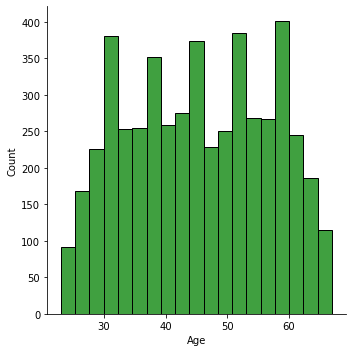

```
KDE of Age
----------------------------------------------------------------------------
```

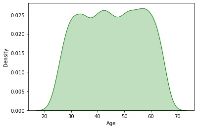

```
BoxPlot of Age
----------------------------------------------------------------------------
```

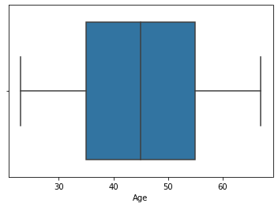

```python
univariateAnalysis_numeric("Age",20)
```

```python
# There are no outliers in Age, and most of the bank's customers are between 35 and 55
```

```
Description of CustomerSince
----------------------------------------------------------------------------
count    4980.000000
mean       20.117671
std        11.468716
min        -3.000000
25%        10.000000
50%        20.000000
75%        30.000000
max        43.000000
Name: CustomerSince, dtype: float64 Distribution of CustomerSince
----------------------------------------------------------------------------
```

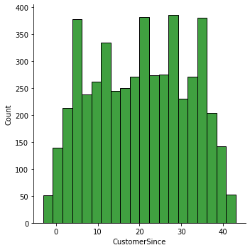

```
KDE of CustomerSince
----------------------------------------------------------------------------
```

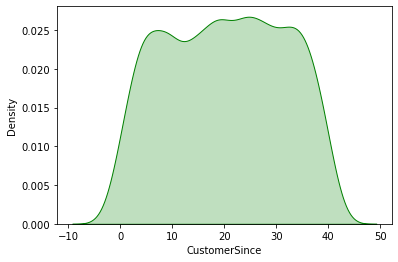

```
BoxPlot of CustomerSince
----------------------------------------------------------------------------
```

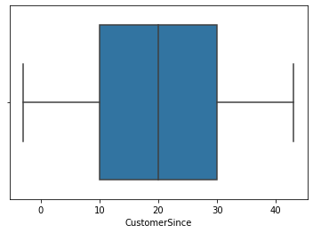

```python
univariateAnalysis_numeric("CustomerSince",20)
```

```python
# There are no outliers in Customer Since
```

```
Description of HighestSpend
----------------------------------------------------------------------------
count    4980.00000
mean       73.85241
std        46.07009
min         8.00000
25%        39.00000
50%        64.00000
75%        98.00000
max       224.00000
Name: HighestSpend, dtype: float64 Distribution of HighestSpend
----------------------------------------------------------------------------
```

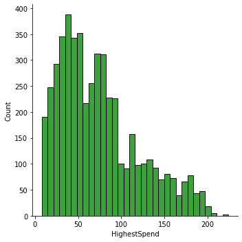

```
KDE of HighestSpend
----------------------------------------------------------------------------
```

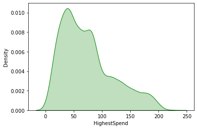

```
BoxPlot of HighestSpend
----------------------------------------------------------------------------
```

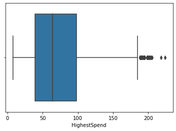

```python
univariateAnalysis_numeric("HighestSpend",20)
```

```python
def treat_outlier(x):
    # taking 5,25,75 percentile of column
    q5= np.percentile(x,5)
    q25=np.percentile(x,25)
    q75=np.percentile(x,75)
    dt=np.percentile(x,95)
    #calculationg IQR range
    IQR=q75-q25
    #Calculating minimum threshold
    lower_bound=q25-(1.5*IQR)
    upper_bound=q75+(1.5*IQR)
    #Capping outliers
    return x.apply(lambda y: dt if y > upper_bound else y).apply(lambda y: q5 if y < lower_bound else y)
```

```
Description of HighestSpend
----------------------------------------------------------------------------
count    4980.000000
mean       73.377871
std        44.928010
min         8.000000
25%        39.000000
50%        64.000000
75%        98.000000
max       185.000000
Name: HighestSpend, dtype: float64 Distribution of HighestSpend
----------------------------------------------------------------------------
```

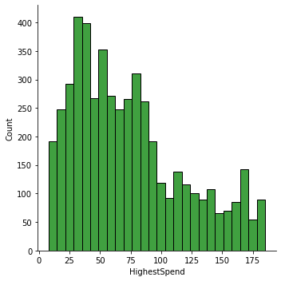

```
KDE of HighestSpend
----------------------------------------------------------------------------
```

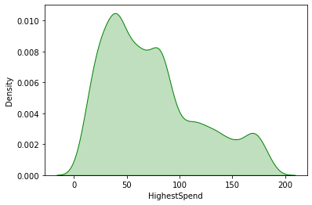

```
BoxPlot of HighestSpend
----------------------------------------------------------------------------
```

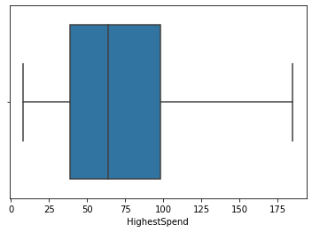

```python
df["HighestSpend"] = treat_outlier(df["HighestSpend"])
univariateAnalysis_numeric("HighestSpend",20)
```

```python
# the data is skewed to the right and there can be High networth customers who will spend more than the majority of the customers. We will treat the outliers so that they do not influence our model
```

```
Description of MonthlyAverageSpend
----------------------------------------------------------------------------
count    4980.000000
mean        1.939536
std         1.750006
min         0.000000
25%         0.700000
50%         1.500000
75%         2.525000
max        10.000000
Name: MonthlyAverageSpend, dtype: float64 Distribution of MonthlyAverageSpend
----------------------------------------------------------------------------
```

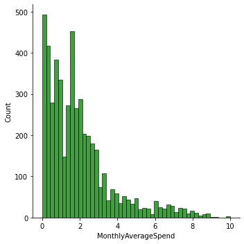

```
KDE of MonthlyAverageSpend
----------------------------------------------------------------------------
```

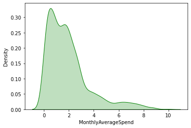

```
BoxPlot of MonthlyAverageSpend
----------------------------------------------------------------------------
```

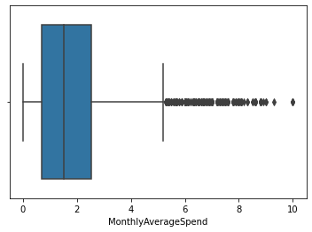

```python
univariateAnalysis_numeric("MonthlyAverageSpend",20)
```

```python
# this is quite similar to hIhgest spend and there are few outliers in our data but as it is normal in banks to have a small set of customers spending more but We will treat the outliers so that they do not influence our model
```

```
Description of MonthlyAverageSpend
----------------------------------------------------------------------------
count    4980.000000
mean        1.884556
std         1.582147
min         0.000000
25%         0.700000
50%         1.500000
75%         2.525000
max         6.000000
Name: MonthlyAverageSpend, dtype: float64 Distribution of MonthlyAverageSpend
----------------------------------------------------------------------------
```

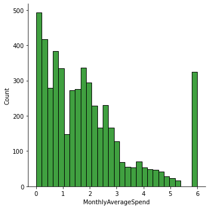

```
KDE of MonthlyAverageSpend
----------------------------------------------------------------------------
```

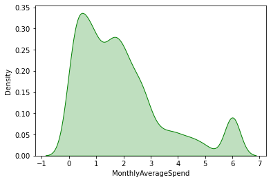

```
BoxPlot of MonthlyAverageSpend
----------------------------------------------------------------------------
```

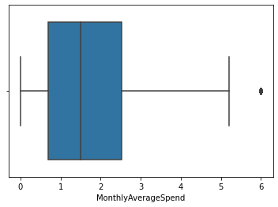

```python
df["MonthlyAverageSpend"] = treat_outlier(df["MonthlyAverageSpend"])
univariateAnalysis_numeric("MonthlyAverageSpend",20)
```

```
Description of Mortgage
----------------------------------------------------------------------------
count    4980.000000
mean       56.589759
std       101.836758
min         0.000000
25%         0.000000
50%         0.000000
75%       101.000000
max       635.000000
Name: Mortgage, dtype: float64 Distribution of Mortgage
----------------------------------------------------------------------------
```

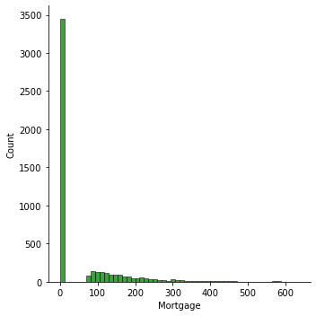

```
KDE of Mortgage
----------------------------------------------------------------------------
```

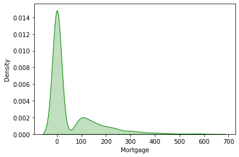

```
BoxPlot of Mortgage
----------------------------------------------------------------------------
```

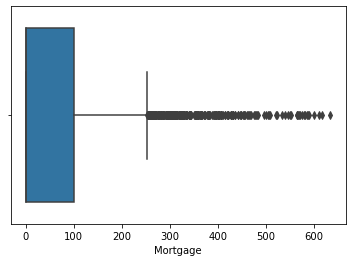

```python
univariateAnalysis_numeric("Mortgage",20)
```

```python
# the data is heavily skewed to the right and assuming that 0 indicates no mortgage, it appears that the majority of the customers do not have mortgage with the bank. We will treat the outliers so that they do not influence our model
```

[output not shown]

[output not shown]

```
Description of MonthlyAverageSpend
----------------------------------------------------------------------------
count    4980.000000
mean        1.884556
std         1.582147
min         0.000000
25%         0.700000
50%         1.500000
75%         2.525000
max         6.000000
Name: MonthlyAverageSpend, dtype: float64 Distribution of MonthlyAverageSpend
----------------------------------------------------------------------------
```

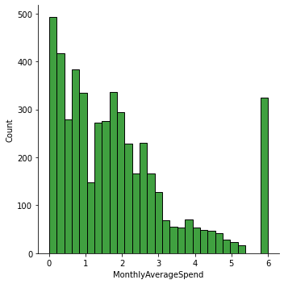

```
KDE of MonthlyAverageSpend
----------------------------------------------------------------------------
```

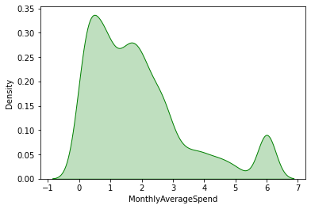

```
BoxPlot of MonthlyAverageSpend
----------------------------------------------------------------------------
```

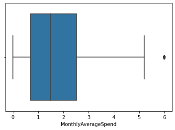

```python
df["MonthlyAverageSpend"] = treat_outlier(df["MonthlyAverageSpend"])
univariateAnalysis_numeric("MonthlyAverageSpend",20)
```

```python
df.select_dtypes(include="category").columns.tolist()
```

```
['HiddenScore',
 'Level',
 'Security',
 'FixedDepositAccount',
 'InternetBanking',
 'CreditCard',
 'LoanOnCard']
```